# Predicting the risk of Heart Disease

### 1.7. Variables distribution and relations with target

Visualization Of Categorical Features

- Smoking
- AlcoholDrinking
- Stroke
- Sex
- AgeCategory
- Race
- PhysicalActivity
- Diabetic
- Asthma
- KidneyDisease
- SkinCancer

1.7.1 first we start to look and how many number of Heart disease cross with Smoking

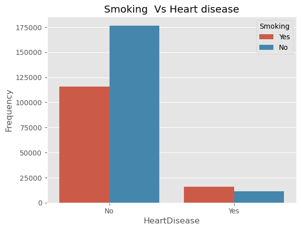

```python
plt.title('Smoking  Vs Heart disease')
sns.countplot(x=df_heart['HeartDisease'],hue=df_heart['Smoking'])
plt.ylabel("Frequency")
plt.show()
```

1.7.2 We check the relation with Alcohol Drinking

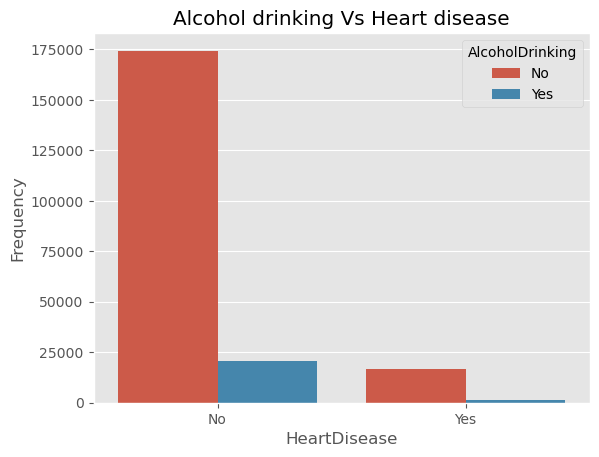

```python
plt.title('Alcohol drinking Vs Heart disease')
sns.countplot(x=df_heart['HeartDisease'],hue=df_heart['AlcoholDrinking'])
plt.ylabel("Frequency")
plt.show()
```

summery:

As showen on abve graph the persentage of people who

- do not drink Alcohol and do not have heart diesases more higher then who who drink Alcohol
- As well the people who drink Alcohol and do not have heart disease more higher than who drink and have heart disease

1.7.3 We check the relation with Stroke

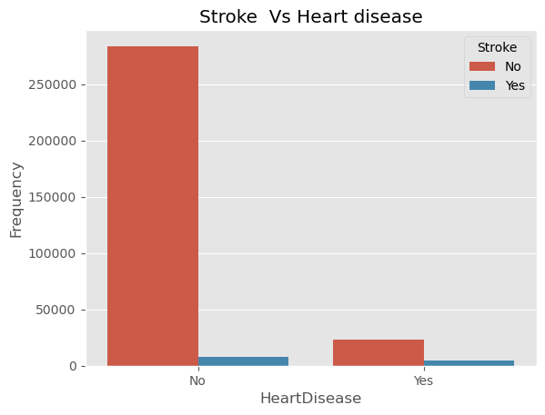

```python
plt.title('Stroke  Vs Heart disease')
sns.countplot(x=df_heart['HeartDisease'],hue=df_heart['Stroke'])
plt.ylabel("Frequency")
plt.show()
```

1.7.5 We check the relation with Sex

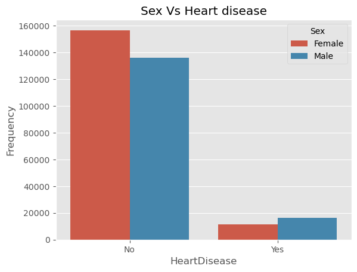

```python
plt.title('Sex Vs Heart disease')
sns.countplot(x=df_heart['HeartDisease'],hue=df_heart['Sex'])
plt.ylabel("Frequency")
plt.show()
```

1.7.5 We check the relation with AgeCategory

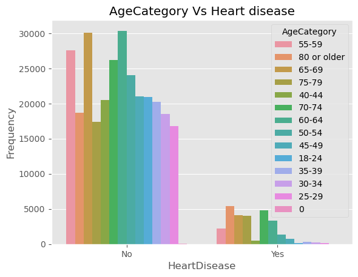

```python
plt.title('AgeCategory Vs Heart disease')
sns.countplot(x=df_heart['HeartDisease'],hue=df_heart['AgeCategory'])
plt.ylabel("Frequency")
plt.show()
```

1.7.6 We check the relation with Race

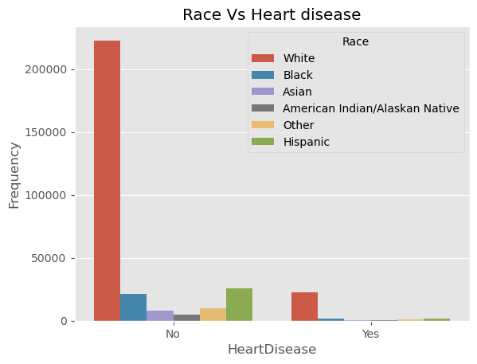

```python
plt.title('Race Vs Heart disease')
sns.countplot(x=df_heart['HeartDisease'],hue=df_heart['Race'])
plt.ylabel("Frequency")
plt.show()
```

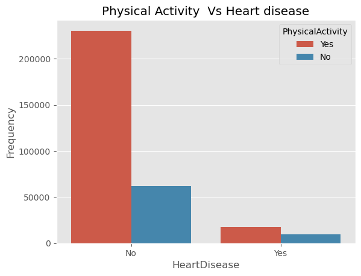

```python
plt.title('Physical Activity  Vs Heart disease')
sns.countplot(x=df_heart['HeartDisease'],hue=df_heart['PhysicalActivity'])
plt.ylabel("Frequency")
plt.show()
```

summery:

As showen on abve graph the persentage of People who have exercise have a very high rate of not getting heart disease

1.7.4 We check the relation with Diabetic

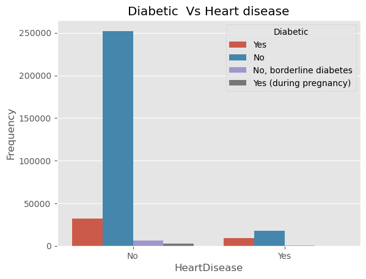

```python
plt.title('Diabetic  Vs Heart disease')
sns.countplot(x=df_heart['HeartDisease'],hue=df_heart['Diabetic'])
plt.ylabel("Frequency")
plt.show()
```

1.7.4 We check the relation with Athema

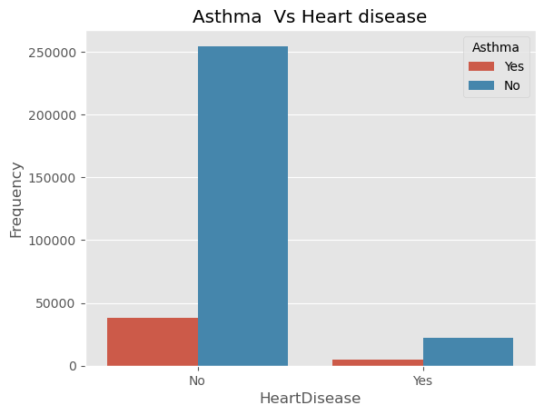

```python
plt.title('Asthma  Vs Heart disease')
sns.countplot(x=df_heart['HeartDisease'],hue=df_heart['Asthma'])
plt.ylabel("Frequency")
plt.show()
```

1.7.4 We check the relation with KidneyDisease

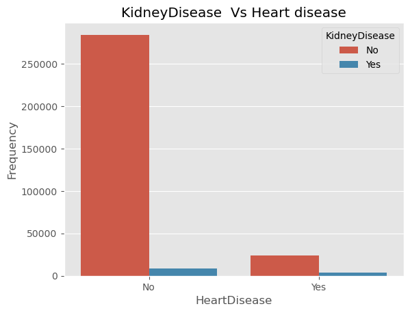

```python
plt.title('KidneyDisease  Vs Heart disease')
sns.countplot(x=df_heart['HeartDisease'],hue=df_heart['KidneyDisease'])
plt.ylabel("Frequency")
plt.show()
```

1.7.4 We check the relation with SkinCancer

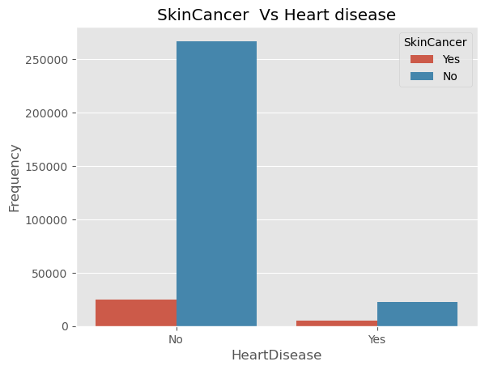

```python
plt.title('SkinCancer  Vs Heart disease')
sns.countplot(x=df_heart['HeartDisease'],hue=df_heart['SkinCancer'])
plt.ylabel("Frequency")
plt.show()
```

```python
df_heart.head(1)
```

|  | HeartDisease | BMI | Smoking | AlcoholDrinking | Stroke | PhysicalHealth | MentalHealth | DiffWalking | Sex | AgeCategory | Race | Diabetic | PhysicalActivity | GenHealth | SleepTime | Asthma | KidneyDisease | SkinCancer | HeartDisease_FamilyHistory | State |
| --- | --- | --- | --- | --- | --- | --- | --- | --- | --- | --- | --- | --- | --- | --- | --- | --- | --- | --- | --- | --- |
| 0 | No | 16.60 | Yes | No | No | 3.00 | 30.00 | No | Female | 55-59 | White | Yes | Yes | Very good | 5.00 | Yes | No | Yes | No | MT |

Visualization Of Numrical Features

- BMI
- PhysicalHealth
- MentalHealth
- SleepTime

WE Transform the HeartDisease Values yes=1 and No=0 to use use the Numrical dis.

```python
df_heart =  df_heart[df_heart.columns].replace({'Yes':1, 'No':0})
```

-1- check the relation the Heart Disease with BMI

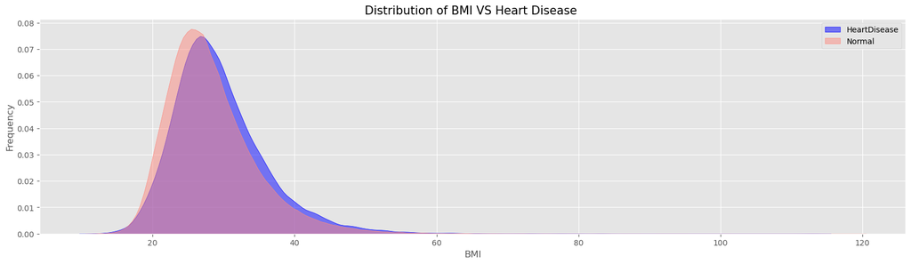

```
NOTE: The Normal BMI is between 18,5 to 24,9
```

```python
fig, x= plt.subplots(figsize = (20,5))
sns.kdeplot(df_heart[df_heart["HeartDisease"]==1]["BMI"], alpha=0.5, color="Blue", label="HeartDisease", shade=True)
sns.kdeplot(df_heart[df_heart["HeartDisease"]==0]["BMI"], alpha=0.5, color="#fc8a80", label="Normal", shade= True)
plt.title('Distribution of BMI VS Heart Disease ', fontsize = 15)
x.set_xlabel("BMI")
x.set_ylabel("Frequency")
x.legend();
plt.show()
print('NOTE: The Normal BMI is between 18,5 to 24,9 ')
```

-2- check the relation the Heart Disease with PhysicalHealth

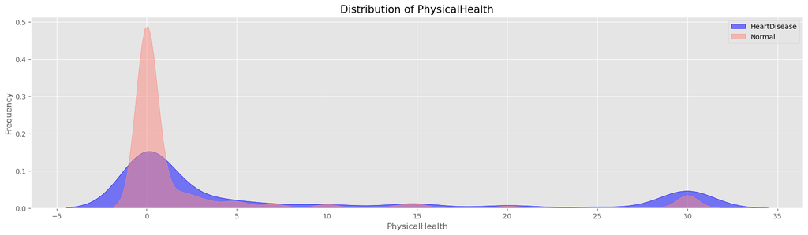

```python
fig, x= plt.subplots(figsize = (20,5))
sns.kdeplot(df_heart[df_heart["HeartDisease"]==1]["PhysicalHealth"], alpha=0.5, color="Blue", label="HeartDisease", shade=True)
sns.kdeplot(df_heart[df_heart["HeartDisease"]==0]["PhysicalHealth"], alpha=0.5, color="#fc8a80", label="Normal", shade= True)
plt.title('Distribution of PhysicalHealth', fontsize = 15)
x.set_xlabel("PhysicalHealth")
x.set_ylabel("Frequency")
x.legend();
plt.show()
```

-3- check the relation the Heart Disease with MentalHealth

[figure not shown]

```python
fig, x= plt.subplots(figsize = (20,5))
sns.kdeplot(df_heart[df_heart["HeartDisease"]==1]["MentalHealth"], alpha=0.5, color="Blue", label="HeartDisease", shade=True)
sns.kdeplot(df_heart[df_heart["HeartDisease"]==0]["MentalHealth"], alpha=0.5, color="#fc8a80", label="Normal", shade= True)
plt.title('Distribution of PhysicalHealth', fontsize = 15)
x.set_xlabel("PhysicalHealth")
x.set_ylabel("Frequency")
x.legend();
plt.show()
```

-4- check the relation the Heart Disease with Sleep time

[figure not shown]

```python
fig, x= plt.subplots(figsize = (20,5))
sns.kdeplot(df_heart[df_heart["HeartDisease"]==1]["SleepTime"], alpha=0.5, color="Blue", label="HeartDisease", shade=True)
sns.kdeplot(df_heart[df_heart["HeartDisease"]==0]["SleepTime"], alpha=0.5, color="#fc8a80", label="Normal", shade= True)
plt.title('Distribution of PhysicalHealth', fontsize = 15)
x.set_xlabel("PhysicalHealth")
x.set_ylabel("Frequency")
x.legend();
plt.show()
```

## MLC2: Data Preparation

Keep a copy of the original dataframe (Better to do so do not mess the orginal data)

```python
df_heart_co=df_heart.copy()
df_heart_co.head(1)
```

|  | HeartDisease | BMI | Smoking | AlcoholDrinking | Stroke | PhysicalHealth | MentalHealth | DiffWalking | Sex | AgeCategory | Race | Diabetic | PhysicalActivity | GenHealth | SleepTime | Asthma | KidneyDisease | SkinCancer | HeartDisease_FamilyHistory | State |
| --- | --- | --- | --- | --- | --- | --- | --- | --- | --- | --- | --- | --- | --- | --- | --- | --- | --- | --- | --- | --- |
| 0 | 0 | 16.60 | 1 | 0.00 | 0.00 | 3.00 | 30.00 | 0 | Female | 55-59 | White | 1 | 1 | Very good | 5.00 | 1 | 0 | 1.00 | 0.00 | MT |

### MLC2.1: Data Cleaning

### 2.1.1. Dealing with variable types

#### From numeric to categorical

Decision trees need variables in a numeric format. However, there are caes in which numeric variables do not have an ordinal interpretation. These variables need to be transformed in order for them to be handled as a categorical variable.

so Far the DATA we have is oki and no need to change anything

```python
df_heart_co.select_dtypes(include=['object']).describe().T
```

|  | count | unique | top | freq |
| --- | --- | --- | --- | --- |
| Sex | 319795 | 2 | Female | 167805 |
| AgeCategory | 319795 | 14 | 65-69 | 34143 |
| Race | 319795 | 6 | White | 245212 |
| Diabetic | 319795 | 4 | 0 | 269653 |
| GenHealth | 319795 | 5 | Very good | 113858 |
| State | 319795 | 51 | OH | 6429 |

### 2.1.2. Imputation of null values

#### Imputation of null values in categorical variables

First need to find the variables with null values and numbers of null value at each variable

```python
df_heart_co.select_dtypes(include=['object']).isnull().sum()
```

```
Sex            0
AgeCategory    0
Race           0
Diabetic       0
GenHealth      0
State          0
dtype: int64
```

##### Imputation of null values in categorical variables

use FILLNA to replace null values

```python
df_heart_co.info()
```

```
<class 'pandas.core.frame.DataFrame'>
RangeIndex: 319795 entries, 0 to 319794
Data columns (total 20 columns):
 #   Column                      Non-Null Count   Dtype
---  ------                      --------------   -----
 0   HeartDisease                319795 non-null  int64
 1   BMI                         319795 non-null  float64
 2   Smoking                     319795 non-null  int64
 3   AlcoholDrinking             212984 non-null  float64
 4   Stroke                      318683 non-null  float64
 5   PhysicalHealth              319795 non-null  float64
 6   MentalHealth                319795 non-null  float64
 7   DiffWalking                 319795 non-null  int64
 8   Sex                         319795 non-null  object
 9   AgeCategory                 319795 non-null  object
 10  Race                        319795 non-null  object
 11  Diabetic                    319795 non-null  object
 12  PhysicalActivity            319795 non-null  int64
 13  GenHealth                   319795 non-null  object
 14  SleepTime                   319795 non-null  float64
 15  Asthma                      319795 non-null  int64
 16  KidneyDisease               319795 non-null  int64
 17  SkinCancer                  319446 non-null  float64
 18  HeartDisease_FamilyHistory  35263 non-null   float64
 19  State                       319795 non-null  object
dtypes: float64(8), int64(6), object(6)
memory usage: 48.8+ MB
```

```python
df_heart_co['AlcoholDrinking'].fillna(value='XXX', inplace=True)
```

```python
df_heart_co['Stroke'].fillna(value='XXX', inplace=True)
```

```python
df_heart_co['SkinCancer'].fillna(value='XXX', inplace=True)
```

```python
df_heart_co['HeartDisease_FamilyHistory'].fillna(value='XXX', inplace=True)
```

```python
df_heart_co.select_dtypes(include=['object']).isnull().sum()
```

```
AlcoholDrinking               0
Stroke                        0
Sex                           0
AgeCategory                   0
Race                          0
Diabetic                      0
GenHealth                     0
SkinCancer                    0
HeartDisease_FamilyHistory    0
State                         0
dtype: int64
```

As showen the all catogirval data have no null values

#### Imputation of null values in numeric variables

```python
df_heart_co.select_dtypes(include=['number']).isnull().sum()
```

```
HeartDisease        0
BMI                 0
Smoking             0
PhysicalHealth      0
MentalHealth        0
DiffWalking         0
PhysicalActivity    0
SleepTime           0
Asthma              0
KidneyDisease       0
dtype: int64
```

As showen the all catogirval data have no null values

#### The final of our data sit after fill the null values

```python
df_heart_co.head().T
```

|  | 0 | 1 | 2 | 3 | 4 |
| --- | --- | --- | --- | --- | --- |
| HeartDisease | 0 | 0 | 0 | 0 | 0 |
| BMI | 16.60 | 20.34 | 26.58 | 24.21 | 23.71 |
| Smoking | 1 | 0 | 1 | 0 | 0 |
| AlcoholDrinking | 0.00 | XXX | XXX | XXX | 0.00 |
| Stroke | 0.00 | 1.00 | 0.00 | 0.00 | 0.00 |
| PhysicalHealth | 3.00 | 0.00 | 20.00 | 0.00 | 28.00 |
| MentalHealth | 30.00 | 0.00 | 30.00 | 0.00 | 0.00 |
| DiffWalking | 0 | 0 | 0 | 0 | 1 |
| Sex | Female | Female | Male | Female | Female |
| AgeCategory | 55-59 | 80 or older | 65-69 | 75-79 | 40-44 |
| Race | White | White | White | White | White |
| Diabetic | 1 | 0 | 1 | 0 | 0 |
| PhysicalActivity | 1 | 1 | 1 | 0 | 1 |
| GenHealth | Very good | Very good | Fair | Good | Very good |
| SleepTime | 5.00 | 7.00 | 8.00 | 6.00 | 8.00 |
| Asthma | 1 | 0 | 1 | 0 | 0 |
| KidneyDisease | 0 | 0 | 0 | 0 | 0 |
| SkinCancer | 1.00 | 0.00 | 0.00 | 1.00 | 0.00 |
| HeartDisease_FamilyHistory | 0.00 | XXX | XXX | 0.00 | XXX |
| State | MT | VT | WY | VT | DC |

### MLC2.2: Data transformation

### 2.2.1 Transformation of categorical variables

```python
df_heart_co.select_dtypes(include=['object']).describe().T
```

|  | count | unique | top | freq |
| --- | --- | --- | --- | --- |
| AlcoholDrinking | 319,795.00 | 3.00 | 0.00 | 191,207.00 |
| Stroke | 319,795.00 | 3.00 | 0.00 | 306,614.00 |
| Sex | 319795 | 2 | Female | 167805 |
| AgeCategory | 319795 | 14 | 65-69 | 34143 |
| Race | 319795 | 6 | White | 245212 |
| Diabetic | 319795 | 4 | 0 | 269653 |
| GenHealth | 319795 | 5 | Very good | 113858 |
| SkinCancer | 319,795.00 | 3.00 | 0.00 | 289,627.00 |
| HeartDisease_FamilyHistory | 319795 | 3 | XXX | 284532 |
| State | 319795 | 51 | OH | 6429 |

#### 2.2.1.1 One hot coding

Show the Data set agian and define which column or cat. have an effect oh heart Disase

```python
df_heart_co
```

|  | HeartDisease | BMI | Smoking | AlcoholDrinking | Stroke | PhysicalHealth | MentalHealth | DiffWalking | Sex | AgeCategory | Race | Diabetic | PhysicalActivity | GenHealth | SleepTime | Asthma | KidneyDisease | SkinCancer | HeartDisease_FamilyHistory | State |
| --- | --- | --- | --- | --- | --- | --- | --- | --- | --- | --- | --- | --- | --- | --- | --- | --- | --- | --- | --- | --- |
| 0 | 0 | 16.60 | 1 | 0.00 | 0.00 | 3.00 | 30.00 | 0 | Female | 55-59 | White | 1 | 1 | Very good | 5.00 | 1 | 0 | 1.00 | 0.00 | MT |
| 1 | 0 | 20.34 | 0 | XXX | 1.00 | 0.00 | 0.00 | 0 | Female | 80 or older | White | 0 | 1 | Very good | 7.00 | 0 | 0 | 0.00 | XXX | VT |
| 2 | 0 | 26.58 | 1 | XXX | 0.00 | 20.00 | 30.00 | 0 | Male | 65-69 | White | 1 | 1 | Fair | 8.00 | 1 | 0 | 0.00 | XXX | WY |
| 3 | 0 | 24.21 | 0 | XXX | 0.00 | 0.00 | 0.00 | 0 | Female | 75-79 | White | 0 | 0 | Good | 6.00 | 0 | 0 | 1.00 | 0.00 | VT |
| 4 | 0 | 23.71 | 0 | 0.00 | 0.00 | 28.00 | 0.00 | 1 | Female | 40-44 | White | 0 | 1 | Very good | 8.00 | 0 | 0 | 0.00 | XXX | DC |
| ... | ... | ... | ... | ... | ... | ... | ... | ... | ... | ... | ... | ... | ... | ... | ... | ... | ... | ... | ... | ... |
| 319790 | 1 | 27.41 | 1 | 0.00 | 0.00 | 7.00 | 0.00 | 1 | Male | 60-64 | Hispanic | 1 | 0 | Fair | 6.00 | 1 | 0 | 0.00 | XXX | AZ |
| 319791 | 0 | 29.84 | 1 | XXX | 0.00 | 0.00 | 0.00 | 0 | Male | 35-39 | Hispanic | 0 | 1 | Very good | 5.00 | 1 | 0 | 0.00 | 0.00 | NH |
| 319792 | 0 | 24.24 | 0 | 0.00 | 0.00 | 0.00 | 0.00 | 0 | Female | 45-49 | Hispanic | 0 | 1 | Good | 6.00 | 0 | 0 | 0.00 | XXX | DE |
| 319793 | 0 | 32.81 | 0 | XXX | 0.00 | 0.00 | 0.00 | 0 | Female | 25-29 | Hispanic | 0 | 0 | Good | 12.00 | 0 | 0 | 0.00 | XXX | UT |
| 319794 | 0 | 46.56 | 0 | XXX | 0.00 | 0.00 | 0.00 | 0 | Female | 80 or older | Hispanic | 0 | 1 | Good | 8.00 | 0 | 0 | 0.00 | XXX | OR |

319795 rows × 20 columns

Also, While the HeartDisease is the traget and the aim of the study we should drop it from the list

```python
# df_heat_co = df_heart_co.drop(['HeartDisease'],axis=1, inplace=True)
# df_heart_co
```

#### we use One-Hot-Encoding to chane or make the veriables from object to 0 /1 code to use in Data modeling

```python
df_heart_co.info()
```

```
<class 'pandas.core.frame.DataFrame'>
RangeIndex: 319795 entries, 0 to 319794
Data columns (total 20 columns):
 #   Column                      Non-Null Count   Dtype
---  ------                      --------------   -----
 0   HeartDisease                319795 non-null  int64
 1   BMI                         319795 non-null  float64
 2   Smoking                     319795 non-null  int64
 3   AlcoholDrinking             319795 non-null  object
 4   Stroke                      319795 non-null  object
 5   PhysicalHealth              319795 non-null  float64
 6   MentalHealth                319795 non-null  float64
 7   DiffWalking                 319795 non-null  int64
 8   Sex                         319795 non-null  object
 9   AgeCategory                 319795 non-null  object
 10  Race                        319795 non-null  object
 11  Diabetic                    319795 non-null  object
 12  PhysicalActivity            319795 non-null  int64
 13  GenHealth                   319795 non-null  object
 14  SleepTime                   319795 non-null  float64
 15  Asthma                      319795 non-null  int64
 16  KidneyDisease               319795 non-null  int64
 17  SkinCancer                  319795 non-null  object
 18  HeartDisease_FamilyHistory  319795 non-null  object
 19  State                       319795 non-null  object
dtypes: float64(4), int64(6), object(10)
memory usage: 48.8+ MB
```

```python
df_heart_co.select_dtypes(include=['object']).describe().T
```

|  | count | unique | top | freq |
| --- | --- | --- | --- | --- |
| AlcoholDrinking | 319,795.00 | 3.00 | 0.00 | 191,207.00 |
| Stroke | 319,795.00 | 3.00 | 0.00 | 306,614.00 |
| Sex | 319795 | 2 | Female | 167805 |
| AgeCategory | 319795 | 14 | 65-69 | 34143 |
| Race | 319795 | 6 | White | 245212 |
| Diabetic | 319795 | 4 | 0 | 269653 |
| GenHealth | 319795 | 5 | Very good | 113858 |
| SkinCancer | 319,795.00 | 3.00 | 0.00 | 289,627.00 |
| HeartDisease_FamilyHistory | 319795 | 3 | XXX | 284532 |
| State | 319795 | 51 | OH | 6429 |

- one-hot-coding for Smoking

```python
_dummy_dataset = pd.get_dummies(df_heart_co['Smoking'], prefix='Smoking')
df_heart_co = pd.concat([df_heart_co,_dummy_dataset],axis=1)
df_heart_co.drop(['Smoking'],axis=1, inplace=True)
```

- one-hot-coding for AlcoholDrinking

```python
_dummy_dataset = pd.get_dummies(df_heart_co['AlcoholDrinking'], prefix='AlcoholDrinking')
df_heart_co = pd.concat([df_heart_co,_dummy_dataset],axis=1)
df_heart_co.drop(['AlcoholDrinking'],axis=1, inplace=True)
```

- one-hot-coding for Strok

```python
_dummy_dataset = pd.get_dummies(df_heart_co['Stroke'], prefix='Stroke')
df_heart_co = pd.concat([df_heart_co,_dummy_dataset],axis=1)
df_heart_co.drop(['Stroke'],axis=1, inplace=True)
```

- one-hot-coding for AgeCategory

```python
_dummy_dataset = pd.get_dummies(df_heart_co['AgeCategory'], prefix='AgeCategory')
df_heart_co = pd.concat([df_heart_co,_dummy_dataset],axis=1)
df_heart_co.drop(['AgeCategory'],axis=1, inplace=True)
```

- one-hot-coding for Race

```python
_dummy_dataset = pd.get_dummies(df_heart_co['Race'], prefix='Race')
df_heart_co = pd.concat([df_heart_co,_dummy_dataset],axis=1)
df_heart_co.drop(['Race'],axis=1, inplace=True)
```

- one-hot-coding for Sex

```python
_dummy_dataset = pd.get_dummies(df_heart_co['Sex'], prefix='Sex')
df_heart_co = pd.concat([df_heart_co,_dummy_dataset],axis=1)
df_heart_co.drop(['Sex'],axis=1, inplace=True)
```

- one-hot-coding for Diabetic

```python
_dummy_dataset = pd.get_dummies(df_heart_co['Diabetic'], prefix='Diabetic')
df_heart_co = pd.concat([df_heart_co,_dummy_dataset],axis=1)
df_heart_co.drop(['Diabetic'],axis=1, inplace=True)
```

- one-hot-coding for PhysicalActivity

```python
_dummy_dataset = pd.get_dummies(df_heart_co['PhysicalActivity'], prefix='PhysicalActivity')
df_heart_co = pd.concat([df_heart_co,_dummy_dataset],axis=1)
df_heart_co.drop(['PhysicalActivity'],axis=1, inplace=True)
```

- one-hot-coding for GenHealth

```python
_dummy_dataset = pd.get_dummies(df_heart_co['GenHealth'], prefix='GenHealth')
df_heart_co = pd.concat([df_heart_co,_dummy_dataset],axis=1)
df_heart_co.drop(['GenHealth'],axis=1, inplace=True)
```

- one-hot-coding for SkinCancer

```python
_dummy_dataset = pd.get_dummies(df_heart_co['SkinCancer'], prefix='SkinCancer')
df_heart_co = pd.concat([df_heart_co,_dummy_dataset],axis=1)
df_heart_co.drop(['SkinCancer'],axis=1, inplace=True)
```

- one-hot-coding for Family Hitory

```python
_dummy_dataset = pd.get_dummies(df_heart_co['HeartDisease_FamilyHistory'], prefix='HeartDisease_FamilyHistory')
df_heart_co = pd.concat([df_heart_co,_dummy_dataset],axis=1)
df_heart_co.drop(['HeartDisease_FamilyHistory'],axis=1, inplace=True)
```

- one-hot-coding for State

```python
_dummy_dataset = pd.get_dummies(df_heart_co['State'], prefix='State')
df_heart_co = pd.concat([df_heart_co,_dummy_dataset],axis=1)
df_heart_co.drop(['State'],axis=1, inplace=True)
```

### 2.2.1.2 Final Data Frame

- - Final Look of the data after one Encoding :

```python
df_heart_co.head(10).T
```

|  | 0 | 1 | 2 | 3 | 4 | 5 | 6 | 7 | 8 | 9 |
| --- | --- | --- | --- | --- | --- | --- | --- | --- | --- | --- |
| HeartDisease | 0.00 | 0.00 | 0.00 | 0.00 | 0.00 | 1.00 | 0.00 | 0.00 | 0.00 | 0.00 |
| BMI | 16.60 | 20.34 | 26.58 | 24.21 | 23.71 | 28.87 | 21.63 | 31.64 | 26.45 | 40.69 |
| PhysicalHealth | 3.00 | 0.00 | 20.00 | 0.00 | 28.00 | 6.00 | 15.00 | 5.00 | 0.00 | 0.00 |
| MentalHealth | 30.00 | 0.00 | 30.00 | 0.00 | 0.00 | 0.00 | 0.00 | 0.00 | 0.00 | 0.00 |
| DiffWalking | 0.00 | 0.00 | 0.00 | 0.00 | 1.00 | 1.00 | 0.00 | 1.00 | 0.00 | 1.00 |
| SleepTime | 5.00 | 7.00 | 8.00 | 6.00 | 8.00 | 12.00 | 4.00 | 9.00 | 5.00 | 10.00 |
| Asthma | 1.00 | 0.00 | 1.00 | 0.00 | 0.00 | 0.00 | 1.00 | 1.00 | 0.00 | 0.00 |
| KidneyDisease | 0.00 | 0.00 | 0.00 | 0.00 | 0.00 | 0.00 | 0.00 | 0.00 | 1.00 | 0.00 |
| Smoking_0 | 0.00 | 1.00 | 0.00 | 1.00 | 1.00 | 0.00 | 1.00 | 0.00 | 1.00 | 1.00 |
| Smoking_1 | 1.00 | 0.00 | 1.00 | 0.00 | 0.00 | 1.00 | 0.00 | 1.00 | 0.00 | 0.00 |
| AlcoholDrinking_0.0 | 1.00 | 0.00 | 0.00 | 0.00 | 1.00 | 1.00 | 1.00 | 1.00 | 1.00 | 1.00 |
| AlcoholDrinking_1.0 | 0.00 | 0.00 | 0.00 | 0.00 | 0.00 | 0.00 | 0.00 | 0.00 | 0.00 | 0.00 |
| AlcoholDrinking_XXX | 0.00 | 1.00 | 1.00 | 1.00 | 0.00 | 0.00 | 0.00 | 0.00 | 0.00 | 0.00 |
| Stroke_0.0 | 1.00 | 0.00 | 1.00 | 1.00 | 1.00 | 1.00 | 1.00 | 1.00 | 1.00 | 1.00 |
| Stroke_1.0 | 0.00 | 1.00 | 0.00 | 0.00 | 0.00 | 0.00 | 0.00 | 0.00 | 0.00 | 0.00 |
| Stroke_XXX | 0.00 | 0.00 | 0.00 | 0.00 | 0.00 | 0.00 | 0.00 | 0.00 | 0.00 | 0.00 |
| AgeCategory_0 | 0.00 | 0.00 | 0.00 | 0.00 | 0.00 | 0.00 | 0.00 | 0.00 | 0.00 | 0.00 |
| AgeCategory_18-24 | 0.00 | 0.00 | 0.00 | 0.00 | 0.00 | 0.00 | 0.00 | 0.00 | 0.00 | 0.00 |
| AgeCategory_25-29 | 0.00 | 0.00 | 0.00 | 0.00 | 0.00 | 0.00 | 0.00 | 0.00 | 0.00 | 0.00 |
| AgeCategory_30-34 | 0.00 | 0.00 | 0.00 | 0.00 | 0.00 | 0.00 | 0.00 | 0.00 | 0.00 | 0.00 |
| AgeCategory_35-39 | 0.00 | 0.00 | 0.00 | 0.00 | 0.00 | 0.00 | 0.00 | 0.00 | 0.00 | 0.00 |
| AgeCategory_40-44 | 0.00 | 0.00 | 0.00 | 0.00 | 1.00 | 0.00 | 0.00 | 0.00 | 0.00 | 0.00 |
| AgeCategory_45-49 | 0.00 | 0.00 | 0.00 | 0.00 | 0.00 | 0.00 | 0.00 | 0.00 | 0.00 | 0.00 |
| AgeCategory_50-54 | 0.00 | 0.00 | 0.00 | 0.00 | 0.00 | 0.00 | 0.00 | 0.00 | 0.00 | 0.00 |
| AgeCategory_55-59 | 1.00 | 0.00 | 0.00 | 0.00 | 0.00 | 0.00 | 0.00 | 0.00 | 0.00 | 0.00 |
| AgeCategory_60-64 | 0.00 | 0.00 | 0.00 | 0.00 | 0.00 | 0.00 | 0.00 | 0.00 | 0.00 | 0.00 |
| AgeCategory_65-69 | 0.00 | 0.00 | 1.00 | 0.00 | 0.00 | 0.00 | 0.00 | 0.00 | 0.00 | 1.00 |
| AgeCategory_70-74 | 0.00 | 0.00 | 0.00 | 0.00 | 0.00 | 0.00 | 1.00 | 0.00 | 0.00 | 0.00 |
| AgeCategory_75-79 | 0.00 | 0.00 | 0.00 | 1.00 | 0.00 | 1.00 | 0.00 | 0.00 | 0.00 | 0.00 |
| AgeCategory_80 or older | 0.00 | 1.00 | 0.00 | 0.00 | 0.00 | 0.00 | 0.00 | 1.00 | 1.00 | 0.00 |

[output cut: 76 more lines]

## MLC3. Modelling

### MLC3.1. Dataset partition and sampling

we import some libraries from Sklearn for validation strategies and model selection

```python
from sklearn import model_selection
from sklearn import metrics
from sklearn.tree import DecisionTreeClassifier
from sklearn import tree
from sklearn.ensemble import RandomForestClassifier, GradientBoostingClassifier
```

- MUST READ (SHADY)

If we check the documentation we can see the validation strategies available in **model_selection**, including random holdout (**train_test_split**), k-fold-validation (**KFold**), or LeaveOneOut

### a) Train/validation split

- Select Features

becaus the Limited time I have and I ue my laptop for differnet work (Sorry Pedro)

```python
features = df_heart_co.drop(columns =['HeartDisease'], axis = 1)
features
```

|  | BMI | PhysicalHealth | MentalHealth | DiffWalking | SleepTime | Asthma | KidneyDisease | Smoking_0 | Smoking_1 | AlcoholDrinking_0.0 | ... | State_SD | State_TN | State_TX | State_UT | State_VA | State_VT | State_WA | State_WI | State_WV | State_WY |
| --- | --- | --- | --- | --- | --- | --- | --- | --- | --- | --- | --- | --- | --- | --- | --- | --- | --- | --- | --- | --- | --- |
| 0 | 16.60 | 3.00 | 30.00 | 0 | 5.00 | 1 | 0 | 0 | 1 | 1 | ... | 0 | 0 | 0 | 0 | 0 | 0 | 0 | 0 | 0 | 0 |
| 1 | 20.34 | 0.00 | 0.00 | 0 | 7.00 | 0 | 0 | 1 | 0 | 0 | ... | 0 | 0 | 0 | 0 | 0 | 1 | 0 | 0 | 0 | 0 |
| 2 | 26.58 | 20.00 | 30.00 | 0 | 8.00 | 1 | 0 | 0 | 1 | 0 | ... | 0 | 0 | 0 | 0 | 0 | 0 | 0 | 0 | 0 | 1 |
| 3 | 24.21 | 0.00 | 0.00 | 0 | 6.00 | 0 | 0 | 1 | 0 | 0 | ... | 0 | 0 | 0 | 0 | 0 | 1 | 0 | 0 | 0 | 0 |
| 4 | 23.71 | 28.00 | 0.00 | 1 | 8.00 | 0 | 0 | 1 | 0 | 1 | ... | 0 | 0 | 0 | 0 | 0 | 0 | 0 | 0 | 0 | 0 |
| ... | ... | ... | ... | ... | ... | ... | ... | ... | ... | ... | ... | ... | ... | ... | ... | ... | ... | ... | ... | ... | ... |
| 319790 | 27.41 | 7.00 | 0.00 | 1 | 6.00 | 1 | 0 | 0 | 1 | 1 | ... | 0 | 0 | 0 | 0 | 0 | 0 | 0 | 0 | 0 | 0 |
| 319791 | 29.84 | 0.00 | 0.00 | 0 | 5.00 | 1 | 0 | 0 | 1 | 0 | ... | 0 | 0 | 0 | 0 | 0 | 0 | 0 | 0 | 0 | 0 |
| 319792 | 24.24 | 0.00 | 0.00 | 0 | 6.00 | 0 | 0 | 1 | 0 | 1 | ... | 0 | 0 | 0 | 0 | 0 | 0 | 0 | 0 | 0 | 0 |
| 319793 | 32.81 | 0.00 | 0.00 | 0 | 12.00 | 0 | 0 | 1 | 0 | 0 | ... | 0 | 0 | 0 | 1 | 0 | 0 | 0 | 0 | 0 | 0 |
| 319794 | 46.56 | 0.00 | 0.00 | 0 | 8.00 | 0 | 0 | 1 | 0 | 0 | ... | 0 | 0 | 0 | 0 | 0 | 0 | 0 | 0 | 0 | 0 |

319795 rows × 105 columns

- Select Target

```python
target = df_heart_co[['HeartDisease']]
target
```

|  | HeartDisease |
| --- | --- |
| 0 | 0 |
| 1 | 0 |
| 2 | 0 |
| 3 | 0 |
| 4 | 0 |
| ... | ... |
| 319790 | 1 |
| 319791 | 0 |
| 319792 | 0 |
| 319793 | 0 |
| 319794 | 0 |

319795 rows × 1 columns

### Set Training and Testing Data

```python
from sklearn.model_selection import train_test_split
X_train, X_test, y_train, y_test = train_test_split(features, target, shuffle = False, test_size = .2, random_state = 40)


print('Shape of training feature:', X_train.shape)
print('Shape of testing feature:', X_test.shape)
print('Shape of training Target:', y_train.shape)
print('Shape of training Target:', y_test.shape)
```

```
Shape of training feature: (255836, 105)
Shape of testing feature: (63959, 105)
Shape of training Target: (255836, 1)
Shape of training Target: (63959, 1)
```

```python
X_train.info(verbose=False)
```

```
<class 'pandas.core.frame.DataFrame'>
Int64Index: 255836 entries, 0 to 255835
Columns: 105 entries, BMI to State_WY
dtypes: float64(4), int64(3), uint8(98)
memory usage: 39.5 MB
```

```python
X_test.info(verbose=False)
```

```
<class 'pandas.core.frame.DataFrame'>
Int64Index: 63959 entries, 255836 to 319794
Columns: 105 entries, BMI to State_WY
dtypes: float64(4), int64(3), uint8(98)
memory usage: 9.9 MB
```

```python
X_train.describe().T.head(5)
```

|  | count | mean | std | min | 25% | 50% | 75% | max |
| --- | --- | --- | --- | --- | --- | --- | --- | --- |
| BMI | 255,836.00 | 28.31 | 6.36 | 12.02 | 24.02 | 27.32 | 31.38 | 113.00 |
| PhysicalHealth | 255,836.00 | 3.34 | 7.91 | 0.00 | 0.00 | 0.00 | 2.00 | 30.00 |
| MentalHealth | 255,836.00 | 3.88 | 7.94 | 0.00 | 0.00 | 0.00 | 3.00 | 30.00 |
| DiffWalking | 255,836.00 | 0.14 | 0.35 | 0.00 | 0.00 | 0.00 | 0.00 | 1.00 |
| SleepTime | 255,836.00 | 7.10 | 1.44 | 1.00 | 6.00 | 7.00 | 8.00 | 24.00 |

```python
X_test.describe().T.head(5)
```

|  | count | mean | std | min | 25% | 50% | 75% | max |
| --- | --- | --- | --- | --- | --- | --- | --- | --- |
| BMI | 63,959.00 | 28.38 | 6.40 | 12.40 | 24.03 | 27.37 | 31.53 | 119.00 |
| PhysicalHealth | 63,959.00 | 3.51 | 8.09 | 0.00 | 0.00 | 0.00 | 2.00 | 30.00 |
| MentalHealth | 63,959.00 | 3.96 | 8.03 | 0.00 | 0.00 | 0.00 | 3.00 | 30.00 |
| DiffWalking | 63,959.00 | 0.14 | 0.34 | 0.00 | 0.00 | 0.00 | 0.00 | 1.00 |
| SleepTime | 63,959.00 | 7.08 | 1.44 | 1.00 | 6.00 | 7.00 | 8.00 | 24.00 |

```python
print(y_train.shape)
print(y_test.shape)
```

```
(255836, 1)
(63959, 1)
```

```python
print('Data in Train:')
print(y_train['HeartDisease'].value_counts())


print('Data in test:')
print(y_test['HeartDisease'].value_counts())
```

```
Data in Train:
0    233851
1     21985
Name: HeartDisease, dtype: int64
Data in test:
0    58571
1     5388
Name: HeartDisease, dtype: int64
```

As showen up , that dataset is not balanced, there is more number of people who have no Heart Disease than people with Heart Disease. This can be fixed by oversampling the data

### MLC3.2. Model definition

```python
from sklearn.tree import DecisionTreeClassifier
from sklearn import tree

from sklearn.metrics import accuracy_score
```

### First comparing the Accuracy between differnt Models and try to see which one reach the most Accuracy ! and then we start to model accroding to it .

- 1 Naive Bayes classifier

```python
from sklearn.naive_bayes import GaussianNB
```

```python
model_1 = GaussianNB()
model_1.fit(X_train, y_train)
ac1=model_1.score(X_test, y_test)
ac1
```

```
0.7399584108569552
```

- 2 Decision Tree Classifier

```python
model_2 = tree.DecisionTreeClassifier()
model_2.fit(X_train, y_train)
ac2=model_2.score(X_test, y_test)
ac2
```

```
0.8700261104770244
```

- 3 RandomForest Classifier

```python
model_3 = RandomForestClassifier()
model_3.fit(X_train, y_train)
ac3=model_3.score(X_test, y_test)
ac3
```

```
0.9141324911271284
```

- 4 KNeighborsClassifier

```python
from sklearn.neighbors import KNeighborsClassifier
```

```python
model_4 = KNeighborsClassifier()
model_4.fit(X_train,np.ravel(y_train))
ac4=model_4.score(X_test, np.ravel(y_test))
ac4
```

```
0.9093481761753623
```

### Comparing Algo. Learning Models using their scores of Accuracy

```python
Accuracy = [ac1,ac2,ac3,ac4]
models = ['NaiveBayesClassifier',
          'Decision Tree Classifier',
          'RandomForestClassifier',
          'KNeighborsClassifier']

acc_df = pd.DataFrame({'Algorithms': models, 'Accuracy': Accuracy})
acc_df.style.background_gradient(cmap="YlGnBu",high=1,axis=0)
```

|  | Algorithms | Accuracy |
| --- | --- | --- |
| 0 | NaiveBayesClassifier | 0.739958 |
| 1 | Decision Tree Classifier | 0.870026 |
| 2 | RandomForestClassifier | 0.914132 |
| 3 | KNeighborsClassifier | 0.909348 |

Observation :

As showen on the above table that RandomForestClassifier is the most accuret model

I will use and test the Random Forst firstly but I know is not the best Algo. for unbalanced data set . But I will use as Main option of the task better use Decision Tree Classifier becuse works more better with unbalanced data set

### Start Random forst Classifier model

```python
from sklearn.datasets import make_classification
```

```python
rf = RandomForestClassifier(n_estimators=100,
                            max_depth=4,
                            max_features='auto',
                            min_samples_leaf=3,
                            bootstrap=True,
                            n_jobs=-1,
                            random_state=42,
                            class_weight='balanced')
rf.fit(
    X=X_train,
    y=y_train,)
```

```
RandomForestClassifier(class_weight='balanced', max_depth=4, min_samples_leaf=3,
                       n_jobs=-1, random_state=42)
```

```
[Text(0.5, 0.9, 'Diabetic_1 <= 0.5\ngini = 0.5\nsamples = 161660\nvalue = [127918.0, 127918.0]\nclass = HD'),
```

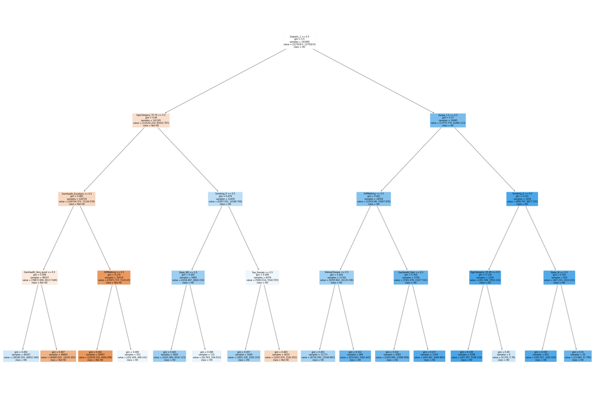

```python
import matplotlib.pyplot as plt
from sklearn.tree import plot_tree

fig = plt.figure(figsize=(30, 20))
plot_tree(rf.estimators_[3],
          class_names = ['Not HD', 'HD'], # HD= Heart Dicsiese
          feature_names=X_test.columns,
          filled=True, impurity=True,
          rounded=True)
```

```python
top_features = pd.Series(rf.feature_importances_, index=X_train.columns).sort_values(ascending=False)
top_features
```

```
DiffWalking                           0.14
Diabetic_1                            0.09
Diabetic_0                            0.08
GenHealth_Fair                        0.08
Stroke_1.0                            0.07
GenHealth_Excellent                   0.06
AgeCategory_80 or older               0.06
PhysicalHealth                        0.06
Stroke_0.0                            0.06
GenHealth_Poor                        0.04
GenHealth_Very good                   0.04
Smoking_1                             0.03
KidneyDisease                         0.02
PhysicalActivity_1                    0.01
AgeCategory_18-24                     0.01
AgeCategory_25-29                     0.01
PhysicalActivity_0                    0.01
SkinCancer_1.0                        0.01
GenHealth_Good                        0.01
AgeCategory_75-79                     0.01
AgeCategory_35-39                     0.01
Sex_Male                              0.01
AgeCategory_30-34                     0.01
AgeCategory_70-74                     0.01
Smoking_0                             0.01
SkinCancer_0.0                        0.01
Sex_Female                            0.00
AgeCategory_40-44                     0.00
Race_White                            0.00
BMI                                   0.00
AgeCategory_45-49                     0.00
SleepTime                             0.00
Race_Hispanic                         0.00
AgeCategory_65-69                     0.00
Diabetic_No, borderline diabetes      0.00
MentalHealth                          0.00
Stroke_XXX                            0.00
AgeCategory_50-54                     0.00
Asthma                                0.00
Race_Black                            0.00
```

[output cut: 51 more lines]

```
State_PA                              0.00
State_AZ                              0.00
State_FL                              0.00
HeartDisease_FamilyHistory_0.0        0.00
AgeCategory_0                         0.00
State_KY                              0.00
State_CT                              0.00
State_IN                              0.00
State_DE                              0.00
State_NE                              0.00
State_NC                              0.00
State_MN                              0.00
State_IA                              0.00
State_WY                              0.00
dtype: float64
```

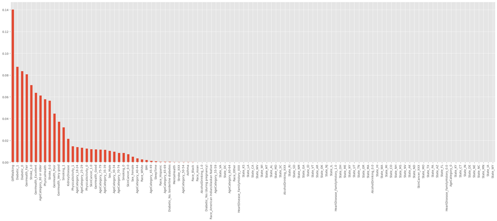

```python
plt.figure(figsize=(30,10))
top_features.plot(kind='bar')
```

Predict the response for test dataset

```python
# y_pred_dt = dt_clf.predict(X_test)
# DTpred = accuracy_score(y_test,y_pred_dt)
# print("Accuracy of DT",DTpred)
```

```python
# fig, ax=plt.subplots(figsize= (50,20))
# tree.plot_tree(dt, ax=ax, fontsize= 5, feature_names= X_test.columns, proportion=True,  filled = True)
```

```python
# #Predict the response for test dataset
# y_pred_dt = dt_clf.predict(X_test)
# DTpred = accuracy_score(y_test,y_pred_dt)
# print("Accuracy of DT",DTpred)
```

### MLC4. Model evaluation

#### MLC4.1 Evaluation over train dataset

pred = predection

```python
y_train_pred = pd.DataFrame(dt.predict(X_train),
                            index=y_train.index,
                            columns=['HD prediction'])

y_train_pred.head()
```

|  | HD prediction |
| --- | --- |
| 0 | 0 |
| 1 | 0 |
| 2 | 0 |
| 3 | 0 |
| 4 | 0 |

```python
y_train.head()
```

|  | HeartDisease |
| --- | --- |
| 0 | 0 |
| 1 | 0 |
| 2 | 0 |
| 3 | 0 |
| 4 | 0 |

```python
print(y_train_pred.shape)
print(y_train.shape)
```

```
(255836, 1)
(255836, 1)
```

```python
df_results = y_train.join(y_train_pred, how= 'inner')
df_results.info()
```

```
<class 'pandas.core.frame.DataFrame'>
Int64Index: 255836 entries, 0 to 255835
Data columns (total 2 columns):
 #   Column         Non-Null Count   Dtype
---  ------         --------------   -----
 0   HeartDisease   255836 non-null  int64
 1   HD prediction  255836 non-null  int64
dtypes: int64(2)
memory usage: 13.9 MB
```

```python
df_results['Success'] = (df_results['HeartDisease'] == df_results['HD prediction']).astype(int)
df_results.info()
df_results.head(10)
```

```
<class 'pandas.core.frame.DataFrame'>
Int64Index: 255836 entries, 0 to 255835
Data columns (total 3 columns):
 #   Column         Non-Null Count   Dtype
---  ------         --------------   -----
 0   HeartDisease   255836 non-null  int64
 1   HD prediction  255836 non-null  int64
 2   Success        255836 non-null  int32
dtypes: int32(1), int64(2)
memory usage: 14.9 MB
```

|  | HeartDisease | HD prediction | Success |
| --- | --- | --- | --- |
| 0 | 0 | 0 | 1 |
| 1 | 0 | 0 | 1 |
| 2 | 0 | 0 | 1 |
| 3 | 0 | 0 | 1 |
| 4 | 0 | 0 | 1 |
| 5 | 1 | 0 | 0 |
| 6 | 0 | 0 | 1 |
| 7 | 0 | 0 | 1 |
| 8 | 0 | 0 | 1 |
| 9 | 0 | 0 | 1 |

When I am not sure about if my model doing good or not I would to go farther with confusion matrix to have more check

#### b) Confusion matrix

```python
confusion_matrix = pd.crosstab(df_results['HeartDisease'], df_results['HD prediction'])
confusion_matrix
```

| HD prediction HeartDisease | 0 | 1 |
| --- | --- | --- |
| 0 | 233316 | 535 |
| 1 | 21164 | 821 |

```python
TP = confusion_matrix.iloc[1,1]
TN = confusion_matrix.iloc[0,0]
FP = confusion_matrix.iloc[0,1]
FN = confusion_matrix.iloc[1,0]
accuracy = (TP + TN) / (TP + TN + FP + FN)
Precision = TP / (TP+FP)
Recall = TP/(TP+FN)
print(accuracy)
print(Precision)
print(Recall)
```

```
0.9151839459653841
0.605457227138643
0.03734364339322265
```

```python
pred_train = dt.predict(X_train)
confusion_matrix_m = metrics.confusion_matrix(y_train,pred_train)
tn, fp, fn, tp = confusion_matrix_m.ravel()

Accuracy_m = metrics.accuracy_score(y_train, pred_train)
Precision_m = metrics.precision_score(y_train,pred_train)
Recall_m = metrics.recall_score(y_train,pred_train)

print("Confusion matrix: ", confusion_matrix_m)
print(f"TN = {tn} - FP = {fp} - FN = {fn} - TP = {tp}")

print("Accuracy: ", Accuracy_m)
print("Precision: ", Precision_m)
print("Recall: ", Recall_m)
```

```
Confusion matrix:  [[233316    535]
 [ 21164    821]]
TN = 233316 - FP = 535 - FN = 21164 - TP = 821
Accuracy:  0.9151839459653841
Precision:  0.605457227138643
Recall:  0.03734364339322265
```

Observation:

But I would to go more farther and check the Evaluation over test dataset

#### MLC4.2 Evaluation over test dataset

#### a) Get predictions for the test set

```python
y_test_pred = pd.DataFrame(dt.predict(X_test), index=y_test.index, columns=['HD prediction'])
```

```python
df_results_test = y_test.join(y_test_pred, how= 'inner')
df_results_test['Success'] = (df_results_test['HeartDisease'] == df_results_test['HD prediction']).astype(int)
df_results_test
```

|  | HeartDisease | HD prediction | Success |
| --- | --- | --- | --- |
| 255836 | 0 | 0 | 1 |
| 255837 | 0 | 0 | 1 |
| 255838 | 0 | 0 | 1 |
| 255839 | 0 | 0 | 1 |
| 255840 | 0 | 0 | 1 |
| ... | ... | ... | ... |
| 319790 | 1 | 0 | 0 |
| 319791 | 0 | 0 | 1 |
| 319792 | 0 | 0 | 1 |
| 319793 | 0 | 0 | 1 |
| 319794 | 0 | 0 | 1 |

63959 rows × 3 columns

```python
confusion_matrix_m_test = metrics.confusion_matrix(df_results_test['HeartDisease'],df_results_test['HD prediction'])

tn, fp, fn, tp = confusion_matrix_m_test.ravel()

Accuracy_m_test = metrics.accuracy_score(df_results_test['HeartDisease'], df_results_test['HD prediction'])
Precision_m_test = metrics.precision_score(df_results_test['HeartDisease'],df_results_test['HD prediction'])
Recall_m_test = metrics.recall_score(df_results_test['HeartDisease'],df_results_test['HD prediction'])
f1_m_test = metrics.f1_score(df_results_test['HeartDisease'],df_results_test['HD prediction'])

print("Confusion matrix: ", confusion_matrix_m_test)
print(f"TN = {tn} - FP = {fp} - FN = {fn} - TP = {tp}")
print("Accuracy: ", Accuracy_m_test)
print("Precision: ", Precision_m_test)
print("Recall: ", Recall_m_test)
print("F1 Score: ", f1_m_test)
```

```
Confusion matrix:  [[58438   133]
 [ 5186   202]]
TN = 58438 - FP = 133 - FN = 5186 - TP = 202
Accuracy:  0.9168373489266561
Precision:  0.6029850746268657
Recall:  0.03749072011878248
F1 Score:  0.07059234667132623
```

### b) Check F1 score

```python
from sklearn.metrics import classification_report
```

```python
print(classification_report(y_test,y_test_pred))
```

```
              precision    recall  f1-score   support

           0       0.92      1.00      0.96     58571
           1       0.60      0.04      0.07      5388

    accuracy                           0.92     63959
   macro avg       0.76      0.52      0.51     63959
weighted avg       0.89      0.92      0.88     63959
```

observation

Since this value F1_score of HD is .07 isn’t very close to 1, it tells us that the model does a poor job of predicting

### c) ROC curve

```python
metrics.roc_auc_score(df_results_test['HeartDisease'], df_results_test['HD prediction'])
```

```
0.5176099858981169
```

```python
fpr, tpr, _ = metrics.roc_curve(df_results_test['HeartDisease'], df_results_test['HD prediction'])
```

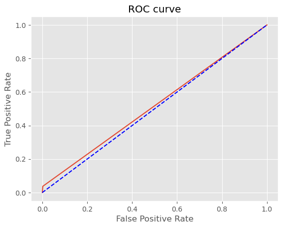

```python
plt.clf()
plt.plot(fpr, tpr)
plt.plot([0, 1], [0, 1], color='blue', linestyle='--')
plt.xlabel('False Positive Rate')
plt.ylabel('True Positive Rate')
plt.title('ROC curve')
plt.show()
```

### 4.3.2. ENSEMBLE MODELS

#### a) Decision Tree model

I chose Decision Tree because, one of the most Algo fits with unbalnced Dataset we have

```python
dt= tree.DecisionTreeClassifier(random_state=42,max_depth=5)
dt.fit(X_train, y_train)
```

```
DecisionTreeClassifier(max_depth=5, random_state=42)
```

```
[Text(0.5, 0.9166666666666666, 'DiffWalking <= 0.5\ngini = 0.157\nsamples = 100.0%\nvalue = [0.914, 0.086]\nclass = Not HD'),
```

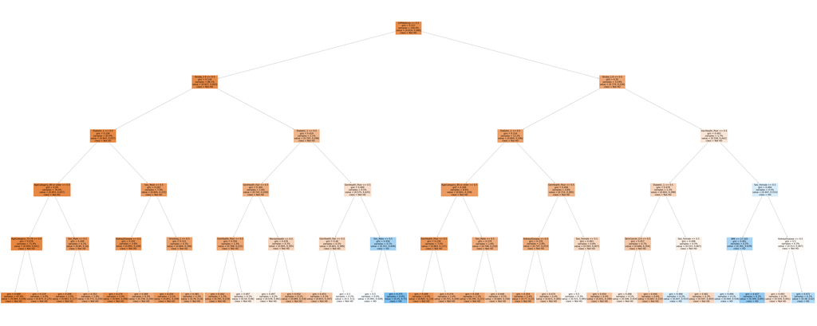

```python
fig, ax = plt.subplots(figsize=(100,40))
tree.plot_tree(dt,
               ax = ax,
               fontsize = 15,
               proportion=True,
               filled = True,
               feature_names = X_test.columns,
               class_names = ['Not HD', 'HD'], # HD= Heart Dicsiese
)
```

```python
top_features_dt = pd.Series(dt.feature_importances_, index=X_train.columns).sort_values(ascending=False)
top_features_dt
```

```
DiffWalking                           0.36
Stroke_1.0                            0.23
Diabetic_1                            0.15
AgeCategory_80 or older               0.08
GenHealth_Poor                        0.05
Sex_Male                              0.04
AgeCategory_75-79                     0.03
KidneyDisease                         0.02
Smoking_1                             0.01
Sex_Female                            0.01
GenHealth_Fair                        0.01
SkinCancer_0.0                        0.00
MentalHealth                          0.00
BMI                                   0.00
State_IL                              0.00
State_ME                              0.00
State_DC                              0.00
State_DE                              0.00
State_MN                              0.00
State_FL                              0.00
State_GA                              0.00
State_HI                              0.00
State_MI                              0.00
State_MD                              0.00
State_IN                              0.00
State_MA                              0.00
State_LA                              0.00
State_IA                              0.00
State_KY                              0.00
State_ID                              0.00
State_KS                              0.00
State_MS                              0.00
State_MO                              0.00
State_NE                              0.00
State_MT                              0.00
State_RI                              0.00
State_WV                              0.00
State_WI                              0.00
State_WA                              0.00
State_VT                              0.00
```

[output cut: 51 more lines]

```
SkinCancer_XXX                        0.00
SkinCancer_1.0                        0.00
GenHealth_Very good                   0.00
GenHealth_Good                        0.00
GenHealth_Excellent                   0.00
PhysicalActivity_1                    0.00
PhysicalActivity_0                    0.00
Diabetic_Yes (during pregnancy)       0.00
Diabetic_No, borderline diabetes      0.00
Diabetic_0                            0.00
Race_White                            0.00
Race_Other                            0.00
Race_Hispanic                         0.00
State_WY                              0.00
dtype: float64
```

[figure not shown]

```python
plt.figure(figsize=(30,10))
top_features.plot(kind='bar')
```

### Model Evluation

a) using the Model

```python
dt_score_train=dt.score(X_train, y_train)
print('the accurancy of the DT scroe for train data is  ',dt_score_train)
```

```
the accurancy of the DT scroe for train data is   0.9151839459653841
```

```python
dt_score_test= dt.score(X_test, y_test)
print('the accurancy of the DT scroe for train data is  ',dt_score_test)
```

```
the accurancy of the DT scroe for train data is   0.9168373489266561
```

b) Evaluation ove the test date

### check the F1 score

```python
y_test_pred_dt = pd.DataFrame({'HeartDisease' : dt.predict(X_test),
                            'HD prediction': dt.predict_proba(X_test)[:,1]},
                            index=y_test.index)
results_df_test_dt= y_test.join(y_test_pred_dt, how= 'inner')
results_df_test_dt['Success'] = (results_df_test_dt['HeartDisease'] == results_df_test_dt['HD prediction']).astype(int)
```

[output not shown]

[output cut: 53 more lines]

[output not shown]

```python
Alg_models = [
    ('RandomForest', RandomForestClassifier(n_estimators=50, max_depth=4, random_state=RANDOM_STATE)),
    ('DecisionTree', DecisionTreeClassifier(max_depth=4, random_state=42)),
]
```

```
ROC AUC Score for RandomForest: 0.8062810544330508
ROC AUC Score for DecisionTree: 0.7259133443167733
```

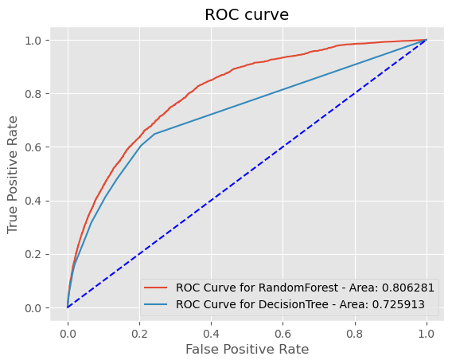

```python
plt.clf()
for z in Alg_models:
    model_name = z[0]
    model_instance = z[1]
    model_instance.fit(X_train,np.ravel(y_train))
    predictions = model_instance.predict_proba(X_test)[:,1]
    auc_score = metrics.roc_auc_score(y_test, predictions)
    print('ROC AUC Score for {}: {}'.format(model_name, auc_score))
    fpr, tpr, _ = metrics.roc_curve(y_test, predictions)
    plt.plot(fpr, tpr, label='ROC Curve for {} - Area: {:2f}'.format(model_name, auc_score))


plt.plot([0, 1], [0, 1], color='Blue', linestyle='--')
plt.xlabel('False Positive Rate')
plt.ylabel('True Positive Rate')
plt.legend(loc="lower right")
plt.title('ROC curve')
plt.show()
```